# A3: Incarceration

### Introduction

The issue of the population of various ethnic groups in prisons is a crucial issue for society and the criminal justice system. and the imprisonment rates of each ethnic group have significant social and human rights impacts, even reflecting racial issues. In this analysis, my goal is to explore trends and patterns in the prison population of each race to gain a deeper understanding of the imprisonment situation. The variable I am going to analyze is the dataset about prison population per county/state. It is based on racial distribution, which is essential for understanding the scope and racial categories of the prison population in the United States. By examining the prison population of each race, we can analyze whether there are potential human rights issues for races with high incarceration rates, which may require further investigation and policy intervention. A deeper understanding of the prison population aims to establish a fair and effective criminal justice system that ensures the rights and well-being of all individuals in society.

### Summary Information

The total population in prison across the United States in 2018 is **327167434** people. The average value of the total population in prison across the United States in 2018 is about **104227** people. The state with the highest total population in prison is California, which is **10120540** people. And the states with the lowest total population in prison are Alaska, Arizona, Colorado, Hawaii, Missouri, New Mexico, and Virginia, which is **0** people. In 2018, the percentage of black prisoners was **8.81%**, and the percentage of white prisoners was **39.43%**. This reflects the significant improvement in racial discrimination in society in 2018, and the criminal justice system adheres to fairness and justice in arresting prisoners. As the 2018 data did not include the total number of black and white prisoners, I used a large population aged 15 to 63.

### The Dataset

The Vera Institute and U.S. Department of Justice Bureau of Justice Statistics (BJS) collected the data, especially the NCRP. The data was collected over several years through different surveys, each focusing on specific aspects of incarceration. NCRP has provided detailed individual-level data on admissions and releases from state prison authorities since 1983. DCRP contains facility-level data on jail average daily populations, admissions, and single-day population counts for the years 2000 to 2013. ASJ provides annual, county-level data on jail admissions, releases, and population estimates for a sample of jurisdictions identified from the Census of Jails since 1982. And COJ collects data from all U.S. counties since 1970. This data is collected to provide detailed information on prison incarceration and related measures throughout the United States. There are **153811 observations** and **36 features** in the data. The issue of imprisonment cannot be separated from social and racial factors. So when processing these prison data, it is necessary to assess the potential impact of analysis to ensure that the results do not lead to bias or racism. Possible limitations and issues with data include missing data, changes in data collection methods, biases brought by racial issues, and misanalyses. Some states and counties may have missing data, resulting in incomplete and unrepresentative analysis. The changes in data collection methods year by year may lead to biases in the data itself, inconsistent data across datasets, and a lack of accuracy in the data. The prejudices brought by racial issues may vary due to the different judicial systems in different regions. The population size of certain races in prisons may not align with the facts and may even be interpreted excessively. When analyzing research data, it may lead to misleading conclusions due to a lack of understanding of the background of the criminal justice system.

### Trends Over Time Chart

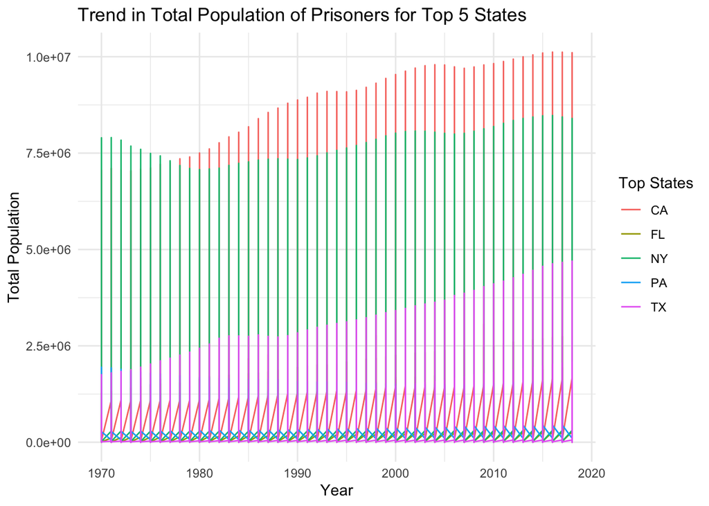

### Variable Comparison Chart

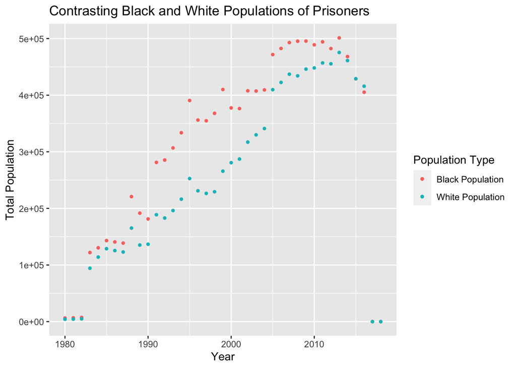

### Map

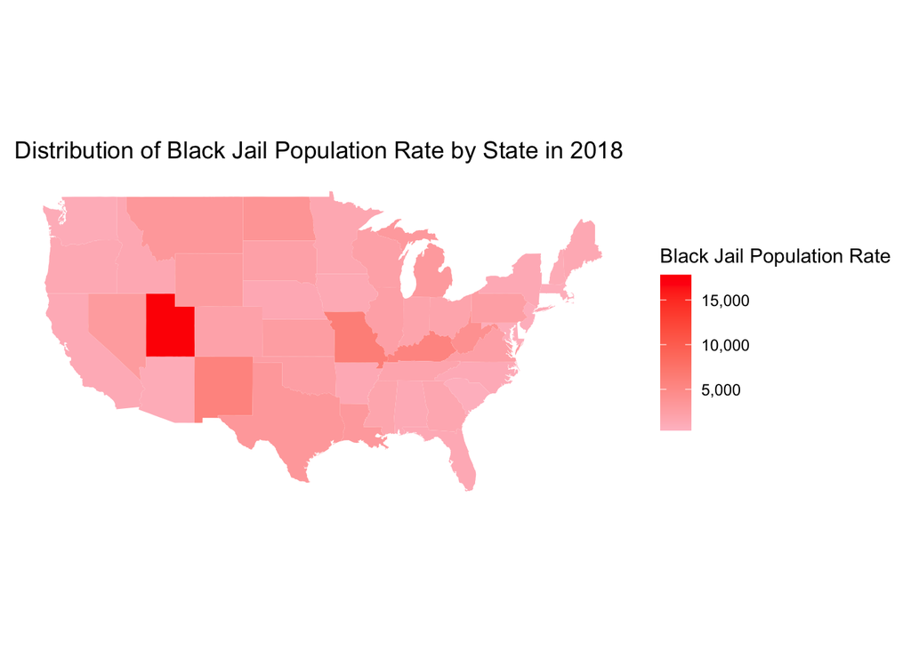

I created a map to display the distribution of the black jail population rate in each state in 2018, showcasing the significant differences in racism issues among states. 2018 was chosen for analysis because it is the year closest to the present in the data and reflects the most social phenomenon. It can be clearly seen in the figure that the middle U.S. region has a higher rate of black imprisonment than West and East America, and Utah has the highest rate of black incarceration. Racism may be closely related to the development and social background of the state. The western and eastern regions of the United States have many large international cities. These regions are usually the financial and technological core of the United States, and their attitude towards minorities may be more inclusive, with more emphasis on racial equality. In contrast, the middle U.S. region may include some economically underdeveloped states, which may be more prone to obvious racism issues. The relationship between regional development and racism has great implications for users to understand the causes and influencing factors of racism.